# Homework 4

```python
import numpy as np
import scipy
from scipy import stats
import matplotlib.pyplot as plt

plt.rcParams["figure.figsize"] = (15,10)
```

## Problem 0: some fake data to mess with

First, let's make a time axis that goes from 0 to 100 π in 1e5 steps

```python
t = np.linspace(0,np.pi*100,int(1e5))
```

Then an offset sinusoid

```python
N = 10+np.sin(t)
```

Then some random background data whose mean and variance depend on N

```python
bkgd = stats.norm.rvs(size=int(1e5))*np.sqrt(N)+N
```

## Problem 1: subsets of data

1a) Make a scatter plot (not a line plot) of the first 1000 data points.

```
[]
```

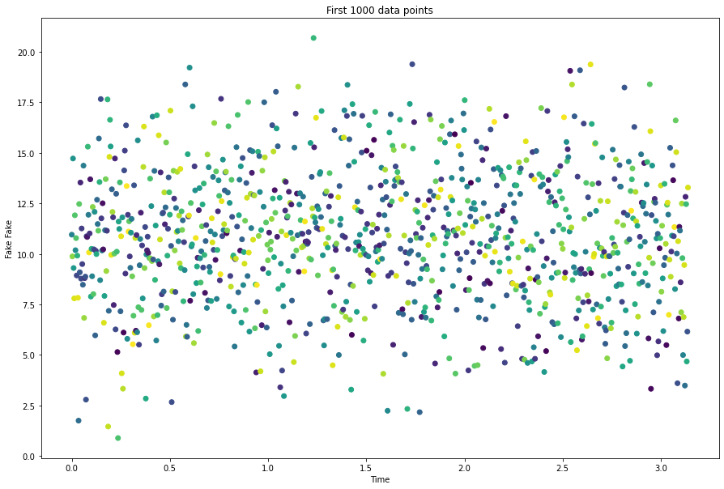

```python
colors = np.random.rand(1000)
plt.scatter(t[0:1000], bkgd[0:1000], c=colors)
plt.xlabel('Time')
plt.ylabel('Fake Fake')
plt.title('First 1000 data points')
plt.plot()
```

1b) Generalize your code so you can make a plot of any X contiguous points (e.g. 2000 points starting at point 500), and produce an example plot of a set of data somethere in the middle of your array.

```
[]
```

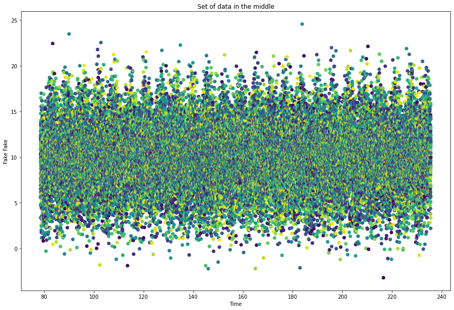

```python
start = int(len(t)/4)
end = int(len(t)/2) + start

colors = np.random.rand(len(t[start:end]))
plt.scatter(t[start:end], bkgd[start:end], c=colors)
plt.xlabel('Time')
plt.ylabel('Fake Fake')
plt.title('Set of data in the middle')
plt.plot()
```

1c) Sampling data, plot every 100th points

```
[]
```

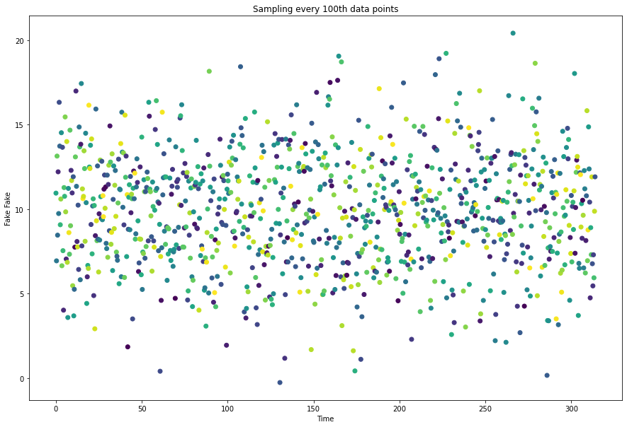

```python
start = 0
end = len(bkgd)
step = 100

colors = np.random.rand(len(t[start:end:step]))
plt.scatter(t[start:end:step], bkgd[start:end:step], c=colors)
plt.xlabel('Time')
plt.ylabel('Fake Fake')
plt.title('Sampling every 100th data points')
plt.plot()
```

## Problem 2: density

Plotting a scatter plot of 100,000 points can get very messy, especially in the central areas where the points all overlap. So instead, we can plot the density of points using a 2D histogram

2a) Make a 2D histogram plot

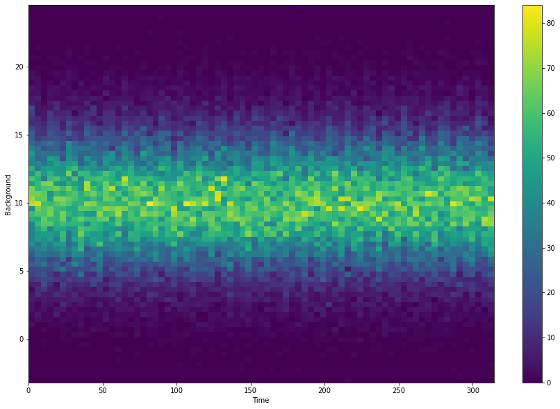

```python
plt.hist2d(t, bkgd, bins=75)
plt.xlabel('Time')
plt.ylabel('Background')
plt.colorbar()
```

2b) Clearly explain what is being plotted in your plot (e.g. what does each color mean?)

Instead of plotting each individual points, we are plotting a density of the data points in some given bins. The colors are bins (densities) they the color bar on the right indicates how many plots are in each bins corresponding to the colors.

## Problem 3: Folding

If we have a periodic signal, it is possible to fold the data stream at that period to make the pattern clearer.

3a) Make an new time variable that folds at a period of 2π (the modulo operator is your friend, variably expressed as mod(), %, or rem()). Then make a scatter plot of all your data, but now folded. (Reminder, for more data you'd never actually want to plot all the points.)

```
[]
```

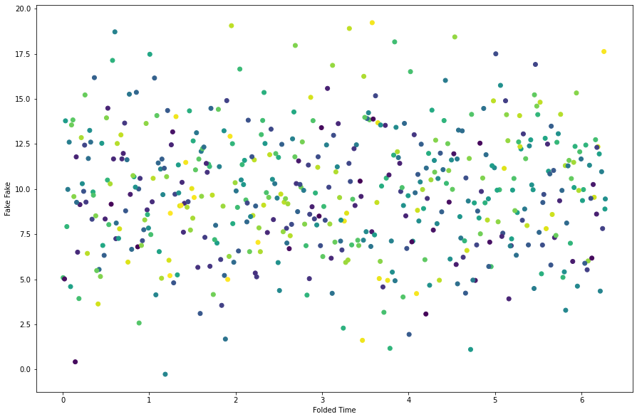

```python
folded_time = t % 2*np.pi



start = int(len(folded_time)/4)
end = int(len(folded_time)/2) + start

colors = np.random.rand(len(folded_time[start:end:step]))
plt.scatter(folded_time[start:end:step], bkgd[start:end:step], c=colors)
plt.xlabel('Folded Time')
plt.ylabel('Fake Fake')
plt.plot()
```

3b) Make a 2D histogram plot of your folded data.

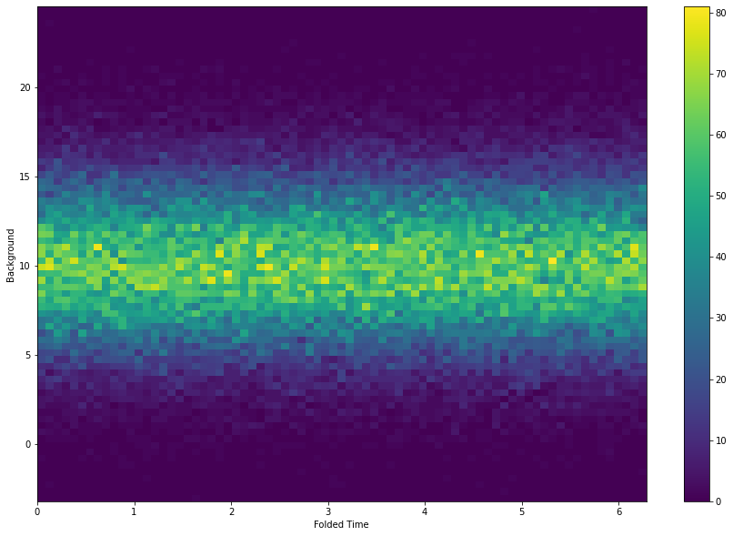

```python
plt.hist2d(folded_time, bkgd, bins=75)
plt.xlabel('Folded Time')
plt.ylabel('Background')
plt.colorbar()
```